# Project Python Foundations: FoodHub Data Analysis

**Marks: 60**

### Context

The number of restaurants in New York is increasing day by day. Lots of students and busy professionals rely on those restaurants due to their hectic lifestyles. Online food delivery service is a great option for them. It provides them with good food from their favorite restaurants. A food aggregator company FoodHub offers access to multiple restaurants through a single smartphone app.

The app allows the restaurants to receive a direct online order from a customer. The app assigns a delivery person from the company to pick up the order after it is confirmed by the restaurant. The delivery person then uses the map to reach the restaurant and waits for the food package. Once the food package is handed over to the delivery person, he/she confirms the pick-up in the app and travels to the customer's location to deliver the food. The delivery person confirms the drop-off in the app after delivering the food package to the customer. The customer can rate the order in the app. The food aggregator earns money by collecting a fixed margin of the delivery order from the restaurants.

### Objective

The food aggregator company has stored the data of the different orders made by the registered customers in their online portal. They want to analyze the data to get a fair idea about the demand of different restaurants which will help them in enhancing their customer experience. Suppose you are hired as a Data Scientist in this company and the Data Science team has shared some of the key questions that need to be answered. Perform the data analysis to find answers to these questions that will help the company to improve the business.

### Data Description

The data contains the different data related to a food order. The detailed data dictionary is given below.

### Data Dictionary

- order_id: Unique ID of the order
- customer_id: ID of the customer who ordered the food
- restaurant_name: Name of the restaurant
- cuisine_type: Cuisine ordered by the customer
- cost: Cost of the order
- day_of_the_week: Indicates whether the order is placed on a weekday or weekend (The weekday is from Monday to Friday and the weekend is Saturday and Sunday)
- rating: Rating given by the customer out of 5
- food_preparation_time: Time (in minutes) taken by the restaurant to prepare the food. This is calculated by taking the difference between the timestamps of the restaurant's order confirmation and the delivery person's pick-up confirmation.
- delivery_time: Time (in minutes) taken by the delivery person to deliver the food package. This is calculated by taking the difference between the timestamps of the delivery person's pick-up confirmation and drop-off information

### Let us start by importing the required libraries

```python
#import libraries for data manipulation
import numpy as np
import pandas as pd

#import libraries for data visualization
import matplotlib.pyplot as plt
import seaborn as sns
```

### Understanding the structure of the data

```python
#uncomment and run the following lines for Google Colab
from google.colab import drive
drive.mount('/content/drive')
```

```python
#read the data
df = pd.read_csv('/content/drive/My Drive/foodhub_order.csv')
#returns the first 5 rows
df.head()
```

|  | order_id | customer_id | restaurant_name | cuisine_type | cost_of_the_order | day_of_the_week | rating | food_preparation_time | delivery_time |
| --- | --- | --- | --- | --- | --- | --- | --- | --- | --- |
| 0 | 1477147 | 337525 | Hangawi | Korean | 30.75 | Weekend | Not given | 25 | 20 |
| 1 | 1477685 | 358141 | Blue Ribbon Sushi Izakaya | Japanese | 12.08 | Weekend | Not given | 25 | 23 |
| 2 | 1477070 | 66393 | Cafe Habana | Mexican | 12.23 | Weekday | 5 | 23 | 28 |
| 3 | 1477334 | 106968 | Blue Ribbon Fried Chicken | American | 29.20 | Weekend | 3 | 25 | 15 |
| 4 | 1478249 | 76942 | Dirty Bird to Go | American | 11.59 | Weekday | 4 | 25 | 24 |

#### Observations:The DataFrame has 9 columns as mentioned in the Data Dictionary. Data in each row corresponds to the order placed by a customer.

### **Question 1:** How many rows and columns are present in the data? [0.5 mark]

```python
print(df.shape) #this is to determine what the dataframe looks like
print("Rows:", df.shape[0]) #this helps locate how many rows
print("Columns:", df.shape[1]) #this helps locate how many columns
```

```
(1898, 9)
Rows: 1898
Columns: 9
```

#### Observations: Based on the output above, there are 1898 rows (representing 1898 orders) and 9 columns.

### **Question 2:** What are the datatypes of the different columns in the dataset? (The info() function can be used) [0.5 mark]

```python
# Use info() to print a concise summary of the DataFrame
df.info()
df.dtypes
```

```
<class 'pandas.core.frame.DataFrame'>
RangeIndex: 1898 entries, 0 to 1897
Data columns (total 9 columns):
 #   Column                 Non-Null Count  Dtype
---  ------                 --------------  -----
 0   order_id               1898 non-null   int64
 1   customer_id            1898 non-null   int64
 2   restaurant_name        1898 non-null   object
 3   cuisine_type           1898 non-null   object
 4   cost_of_the_order      1898 non-null   float64
 5   day_of_the_week        1898 non-null   object
 6   rating                 1898 non-null   object
 7   food_preparation_time  1898 non-null   int64
 8   delivery_time          1898 non-null   int64
dtypes: float64(1), int64(4), object(4)
memory usage: 133.6+ KB
```

|  | 0 |
| --- | --- |
| order_id | int64 |
| customer_id | int64 |
| restaurant_name | object |
| cuisine_type | object |
| cost_of_the_order | float64 |
| day_of_the_week | object |
| rating | object |
| food_preparation_time | int64 |
| delivery_time | int64 |

**dtype:** object

#### Observations: Order_id, customer_id, food_preparation_time,and delivery_time are int64 which would mean that the datatype uses 64 bits of memory to store the integer values. restaurant_name, cuisine_type, day_of_the_week, and rating are objects which would mean that the datatype was a string number. Finally, cost_of_the_order is a float64 which would mean that the datatype uses 64 bits of memory to store the float values. In conclusion, there are int64, objects, and float6 with no rows/columns empty.

### **Question 3:** Are there any missing values in the data? If yes, treat them using an appropriate method. [1 mark]

```python
df['rating'] = df['rating'].replace('Not given', np.nan)
df['rating'] = df['rating'].astype(float)
null_counts = df.isnull().sum().reset_index()
null_counts.columns = ['column', 'count']
null_counts
```

|  | column | count |
| --- | --- | --- |
| 0 | order_id | 0 |
| 1 | customer_id | 0 |
| 2 | restaurant_name | 0 |
| 3 | cuisine_type | 0 |
| 4 | cost_of_the_order | 0 |
| 5 | day_of_the_week | 0 |
| 6 | rating | 736 |
| 7 | food_preparation_time | 0 |
| 8 | delivery_time | 0 |

```python
df.isnull().sum() #this determines the sum of the empty values in the dataframe
temp_df = df.copy()
temp_df['rating'] = temp_df['rating'].replace('Not given', np.nan)
temp_df['rating'] = temp_df['rating'].astype(float)
temp_df = temp_df.dropna(subset=['rating'])
null_counts = temp_df.isnull().sum().reset_index() #I created null_counts to present into a new dataframe
null_counts.columns = ['column', 'count'] #this is to rename the columns for the new dataframes
null_counts  #this presents as a neat table
```

|  | column | count |
| --- | --- | --- |
| 0 | order_id | 0 |
| 1 | customer_id | 0 |
| 2 | restaurant_name | 0 |
| 3 | cuisine_type | 0 |
| 4 | cost_of_the_order | 0 |
| 5 | day_of_the_week | 0 |
| 6 | rating | 0 |
| 7 | food_preparation_time | 0 |
| 8 | delivery_time | 0 |

#### Observations: Based on the table above, there are 0 missing values in the following columns.

### **Question 4:** Check the statistical summary of the data. What is the minimum, average, and maximum time it takes for food to be prepared once an order is placed? [2 marks]

```python
#To find the results manually
df['food_preparation_time'].min() #to calculate the minimum food preparation time
df['food_preparation_time'].mean() #to calculate the average food preparation time
average = round(df['food_preparation_time'].mean(),2) #to define the minimum food preparation time as average to two decimals place
df['food_preparation_time'].max() #to calculate the maximum food preparation time and create the average variable
# To display the answer as an  output
print("The min food preparation time is", df['food_preparation_time'].min(),"minutes.") # to calculate the minimum food preparation time
print("The average food preparation time is", average,"minutes.") # to print the average food preparation time
print("The max food preparation time is", df['food_preparation_time'].max(),"minutes.") # to print the maximum food preparation time
#to find the description of food_preparaption time for statistical summary
prep_time = round(df['food_preparation_time'].describe(),2) # to print the statistical summary of the food preparation time and rounding the value to two decimal points
delivery_time = round(df['delivery_time'].describe(),2) # to print the statistical summary of the delivery time and rounding the value to two decimal points
cost_orders = round(df['cost_of_the_order'].describe(),2) # to print the statistical summary of the cost of the order and rounding the value to two decimal points
rating_description= round(temp_df['rating'].describe(),2) # to print the statistical summary of the data and rounding the value to two decimal points
summary_table = pd.concat([prep_time, delivery_time,cost_orders,rating_description], axis=1) #to create all the summary into one table
summary_table.columns = ['Food Prep Time', 'Delivery Time', 'Order Cost', 'Rating'] # Rename column names for neatness
summary_table
```

```
The min food preparation time is 20 minutes.
The average food preparation time is 27.37 minutes.
The max food preparation time is 35 minutes.
```

|  | Food Prep Time | Delivery Time | Order Cost | Rating |
| --- | --- | --- | --- | --- |
| count | 1898.00 | 1898.00 | 1898.00 | 1162.00 |
| mean | 27.37 | 24.16 | 16.50 | 4.34 |
| std | 4.63 | 4.97 | 7.48 | 0.74 |
| min | 20.00 | 15.00 | 4.47 | 3.00 |
| 25% | 23.00 | 20.00 | 12.08 | 4.00 |
| 50% | 27.00 | 25.00 | 14.14 | 5.00 |
| 75% | 31.00 | 28.00 | 22.30 | 5.00 |
| max | 35.00 | 33.00 | 35.41 | 5.00 |

### **Question 5:** How many orders are not rated? [1 mark]

```python
df['rating'] = df['rating'].replace('Not given', np.nan)
df['rating'] = df['rating'].astype(float)
null_counts = df['rating'].isnull().sum()
print("The number of orders that are not rated is", null_counts, "orders.")
```

```
The number of orders that are not rated is 736 orders.
```

#### Observations: There were 736 orders there were not rated.

### Exploratory Data Analysis (EDA)

### **Question 6:** Explore all the variables and provide observations on their distributions. (Generally, histograms, boxplots, countplots, etc. are used for univariate exploration.) [9 marks]

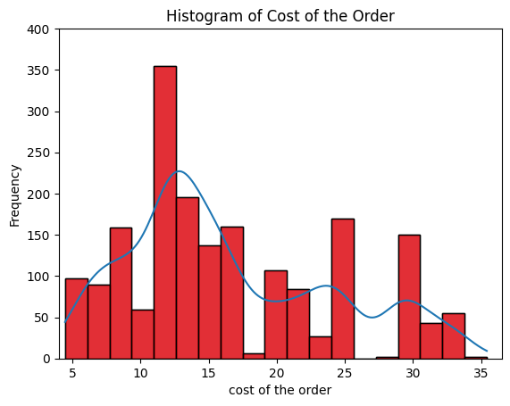

```python
#For Cost of The Order Histogram
sns.histplot(data=df, x = 'cost_of_the_order', kde=True)
plt.title('Histogram of Cost of the Order')  #To change title of the histogram
plt.xlim(4,36.5) #Range of the lowest to highest number on x axis
plt.ylim(0,400) #Range of the lowest to highest number on y axis
plt.xlabel('cost of the order') #Label of the x axis
plt.ylabel('Frequency') #Label of the y axis
sns.histplot(data=df, x='cost_of_the_order', color = 'red')  #To change color
plt.show()
```

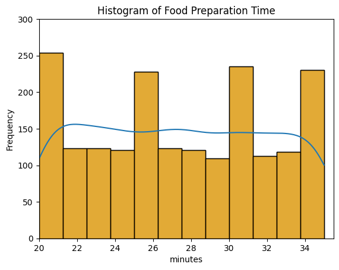

```python
#For Food Preparation Time Histogram
sns.histplot(data=df, x = 'food_preparation_time', kde=True) #this is to create a histogram
plt.title('Histogram of Food Preparation Time')  #To change title of the histogram
plt.xlim(20,35.5) #Range of the lowest to highest number on x axis
plt.ylim(0,300) #Range of the lowest to highest number on y axis
plt.xlabel('minutes') #Label of the x axis
plt.ylabel('Frequency') #Label of the y axis
sns.histplot(data=df, x='food_preparation_time', color = 'orange')  #To change color
plt.show()
```

#### Observations: Based on the graph above, there are mini groups (20-24 ,25-30, 31-34) of histograms clustered together. However, the density curve shows a unimodal curve.

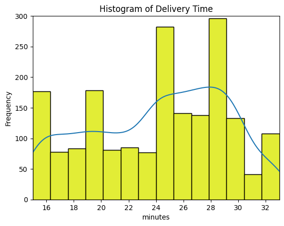

```python
#For Delivery Time Histogram
sns.histplot(data=df, x = 'delivery_time', kde=True) #this is to create the histogram
plt.title('Histogram of Delivery Time')  #To change title of the histogram
plt.xlim(15,33) #Range of the lowest to highest number on x axis
plt.ylim(0,300) #Range of the lowest to highest number on y axis
plt.xlabel('minutes') #Label of the x axis
plt.ylabel('Frequency') #Label of the y axis
sns.histplot(data=df, x='delivery_time', color = 'yellow')  #To change color
plt.show()
```

#### Observations: The histogram shows there are more values from 23-32. It is skewed to the left.

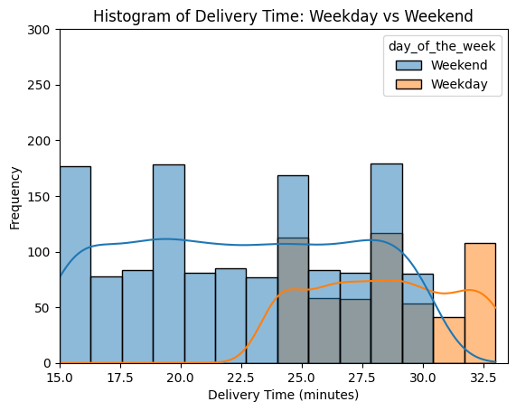

```python
#For Delivery Time (Weekday vs. Weekend) Histogram
sns.histplot(data=df, x='delivery_time', hue='day_of_the_week', kde=True)
plt.title('Histogram of Delivery Time: Weekday vs Weekend') #To change title of the histogram
plt.xlim(15, 33.5) #Range of the lowest to highest number on x axis
plt.ylim(0, 300) #Range of the lowest to highest number on y axis
plt.xlabel('Delivery Time (minutes)') #Label of the x axis
plt.ylabel('Frequency') #Label of the y axis
plt.show()
```

#### Observations: Based on the histogram, above, the Weekend section (in blue) shows a more uniformed distribution towards the 15 - 30 minute section while the Weekday section (in orange) shows a unformed distribution from 24.5 - 32.5 minutes.

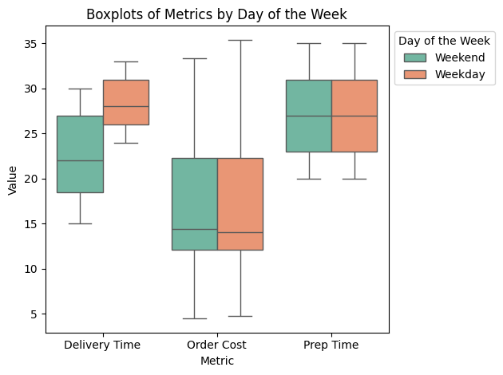

```python
#--BOXPLOT--
delivery = df[['day_of_the_week', 'delivery_time']].copy() #to rename a dataframe by only including the day of the week and delivery time column
delivery['Metric'] = 'Delivery Time'  #to label the x axis measured by delivery time
delivery.rename(columns={'delivery_time': 'Value'}, inplace=True) #To make the y-axis be measured by value

cost_of_order = df[['day_of_the_week', 'cost_of_the_order']].copy()  #to rename a dataframe by only including the day of the week and cost of the order column
cost_of_order['Metric'] = 'Order Cost'  #to label the x axis measured by order cost
cost_of_order.rename(columns={'cost_of_the_order': 'Value'}, inplace=True) #To make the y-axis be measured by value

food_prep = df[['day_of_the_week', 'food_preparation_time']].copy()  #to rename a dataframe by only including the day of the week and food preparation time
food_prep['Metric'] = 'Prep Time'  #to label the x axis measured by order cost
food_prep.rename(columns={'food_preparation_time': 'Value'}, inplace=True) #To make the y-axis be measured by value

combined = pd.concat([delivery, cost_of_order, food_prep]) #to combine the different dataframes into one dataframe

sns.boxplot(data=combined, x='Metric', y='Value', hue='day_of_the_week', palette='Set2') #to differentiate colors based on weekends and weakdays
plt.title('Boxplots of Metrics by Day of the Week') #to create a title
plt.xlabel('Metric') #to label the x axis
plt.ylabel('Value') #to label the x axis
plt.legend(title='Day of the Week', bbox_to_anchor=(1, 1), loc='upper left') #to create a key for clarification
plt.tight_layout() #to ensure ample space to show the graphs
plt.show()
```

#### Observations: It looked like whether it was weekend/weekday, prep time has the same minimum, 25th quartile, median, 75th quartile, and maximum with no outliers. While the 25th and 75th quartile shows the same value, the median is higher in the weekend compared to the weekday by a bit. Finally, the delivery time varied when it came weekdays vs weekend. For instance, the minimum, 25th quartile, and median in the weekend boxplot was a lot lower than the minimum and 25th quartile in the weekday. This could warrant further explanation into why the delivery time is super spread out on the weekends compared to the weekdays.

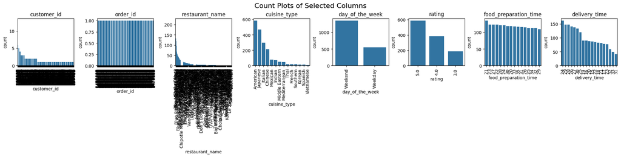

```python
#to create the x-values of the plots
columns_plot = ['customer_id', 'order_id', 'restaurant_name', 'cuisine_type', 'day_of_the_week', 'rating','food_preparation_time','delivery_time'] #the list of columns that I want to observe on a countplot
fig, axes = plt.subplots(1, len(columns_plot), figsize=(20, 5), constrained_layout=True) #to create and resize into one row

for ax, col in zip(axes, columns_plot): #to create a loop so that each column can have its own graph
    sns.countplot(data=df, x=col, order=df[col].value_counts().index, ax=ax)
    ax.set_title(f'{col}')
    ax.tick_params(axis='x', rotation=90)

plt.suptitle("Count Plots of Selected Columns", fontsize=16) #to create a title of the entire column plots
plt.show()
```

### **Question 7**: Which are the top 5 restaurants in terms of the number of orders received? [1 mark]

```python
top_5_df = df['restaurant_name'].value_counts().head(5).reset_index() #to get the top 5 restaurants using head()
top_5_df.index = top_5_df.index + 1 #to rename the index
top_5_df.columns = ['restaurant_name', 'number_of_order'] #to rename the column names
top_5_df
```

|  | restaurant_name | number_of_order |
| --- | --- | --- |
| 1 | Shake Shack | 219 |
| 2 | The Meatball Shop | 132 |
| 3 | Blue Ribbon Sushi | 119 |
| 4 | Blue Ribbon Fried Chicken | 96 |
| 5 | Parm | 68 |

#### Observations: Based on the output above, it showed that Shake Shack had the most orders with 219 orders, followed by The Meatball Shop with 132 orders, Blue Ribbon Sushi with 119 orders, Blue Ribbon Fried Chicken with 96 orders, and Parm with 68 orders.

### **Question 8**: Which is the most popular cuisine on weekends? [1 mark]

```
The most popular cusines on the weekend is: American.
```

|  | cuisine_type | count |
| --- | --- | --- |
| 1 | American | 415 |
| 2 | Japanese | 335 |
| 3 | Italian | 207 |
| 4 | Chinese | 163 |
| 5 | Mexican | 53 |
| 6 | Indian | 49 |
| 7 | Middle Eastern | 32 |
| 8 | Mediterranean | 32 |
| 9 | Thai | 15 |
| 10 | French | 13 |
| 11 | Korean | 11 |
| 12 | Southern | 11 |
| 13 | Spanish | 11 |
| 14 | Vietnamese | 4 |

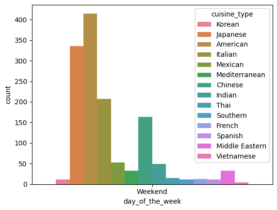

```python
weekend = df[df['day_of_the_week'] == 'Weekend'] #to find all the data that is under weekend
weekend_countplot = sns.countplot(data=weekend, x='day_of_the_week', hue='cuisine_type') #to create a visual of the weekend vs cuisine type
cuisine_total_df = weekend['cuisine_type'].value_counts().reset_index() #this is to show the counts in a column datatype
cuisine_total_df.columns = ['cuisine_type', 'count'] #this is to rename the title of the column
cuisine_total_df.index = cuisine_total_df.index + 1 #this is to rename the index
number_1_cuisine = cuisine_total_df.iloc[0]['cuisine_type'] #to only locate the cuisine that had the highest count
print("The most popular cusines on the weekend is: "+ str(number_1_cuisine)+ ".") #this is to show the output in a sentence
cuisine_total_df
```

#### Observations: Based on the countplot above, the most popular cuisine on the weekend is American cuisine at 415 orders.

### **Question 9**: What percentage of the orders cost more than 20 dollars? [2 marks]

```python
total_orders = len(df) #this shows the number of total orders in their respective rows
orders= df[df['cost_of_the_order'] > 20] # to find the number of orders costing more than $20
percentage = (len(orders) / total_orders) * 100 # to calculate percentage
print("Percentage of orders costing more than $20: " + str(round(percentage, 2)) + "%") #to display the percentage of orders in a sentence
```

```
Percentage of orders costing more than $20: 29.24%
```

#### Observations: The percentage of orders costing more than $20 is 29.24%.

### **Question 10**: What is the mean order delivery time? [1 mark]

```python
average =round(df['delivery_time'].mean(),2) #to calculate the average of the delivery time and round it to two decimal places
print("The average delivery time is", average,"minutes.") #to output the answer in a sentence
```

```
The average delivery time is 24.16 minutes.
```

#### Observations: The average order delivery time is 24.16 minutes.

### **Question 11:** The company has decided to give 20% discount vouchers to the top 5 most frequent customers. Find the IDs of these customers and the number of orders they placed. [1 mark]

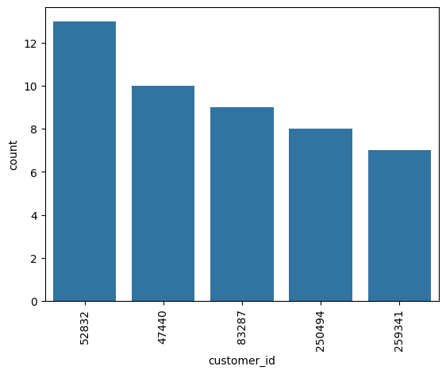

|  | customer_id | order_count |
| --- | --- | --- |
| 1 | 52832 | 13 |
| 2 | 47440 | 10 |
| 3 | 83287 | 9 |
| 4 | 250494 | 8 |
| 5 | 259341 | 7 |

```python
#To find the top 5 customer IDs by order frequency
top_5_customers_df = df['customer_id'].value_counts().index[:5] #this will help locate all the customer ids and order them by value counts. The :5 shows python to run up to the 6th value (6th value is exclusive)
top_5_df = df[df['customer_id'].isin(top_5_customers_df)] #this helps find customer id that is in the top_5_customer dataframe
ordered = top_5_df['customer_id'].value_counts().index #to create a new variable to not confuse the process
# Plot with ordered bars
sns.countplot(data=top_5_df, x='customer_id', order=ordered) #to show the visual
plt.xticks(rotation=90) #to rotate the x axis labels to 90 degrees (horizontal to vertical)
plt.show()
#To find the actual number of orders the top 5 ordered
orders_total = top_5_df['customer_id'].value_counts().reset_index() #this will show the count of orders
orders_total.columns = ['customer_id', 'order_count'] #to rename the table columns
orders_total.index = orders_total.index + 1 #to rename the index
orders_total
```

#### Observations: According to the bar graph above, customer_id 52832 had the most orders with 13 orders followed by customer_id 47440 with 10 orders, customer_id 83287 with 9 orders, customer_id 250494 with 8 orders, and customer_id 259341 with 7 orders.

### **Question 12**: Perform a multivariate analysis to explore relationships between the important variables in the dataset. (It is a good idea to explore relations between numerical variables as well as relations between numerical and categorical variables) [10 marks]

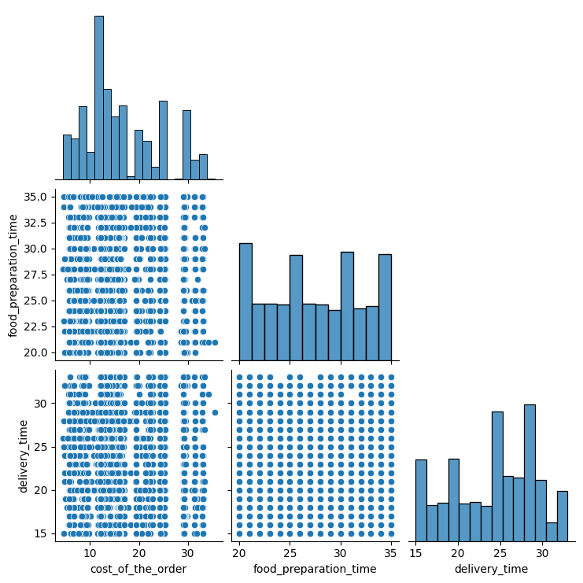

```python
#PAIRPLOT
sns.pairplot(data=df[['restaurant_name','cuisine_type','cost_of_the_order','day_of_the_week','rating','food_preparation_time','delivery_time']], corner = True)
plt.show()
```

#### Observations: Between cost of the order and food preparation time, there were no correlations and therefore, no line of best fit in the pairplots. I would not work with these graphs as these graphs don't provide much insight into the respective columns.

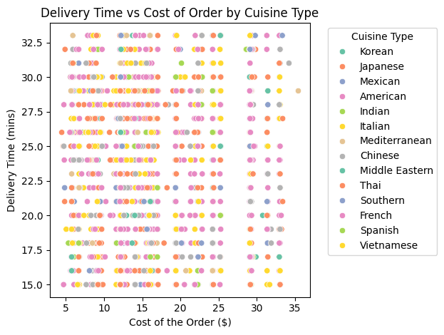

```python
#SCATTERPLOT
sns.scatterplot(data=df, x='cost_of_the_order', y='delivery_time', hue='cuisine_type', palette='Set2')
plt.title('Delivery Time vs Cost of Order by Cuisine Type')
plt.xlabel('Cost of the Order ($)')
plt.ylabel('Delivery Time (mins)')
plt.legend(title='Cuisine Type', bbox_to_anchor=(1.05, 1), loc='upper left')
plt.tight_layout()
plt.show()
```

#### Observations: There are no correlations between cost of the order and delivery time. Like the pairplots, there are no insights that are possible to gain from these graphs.

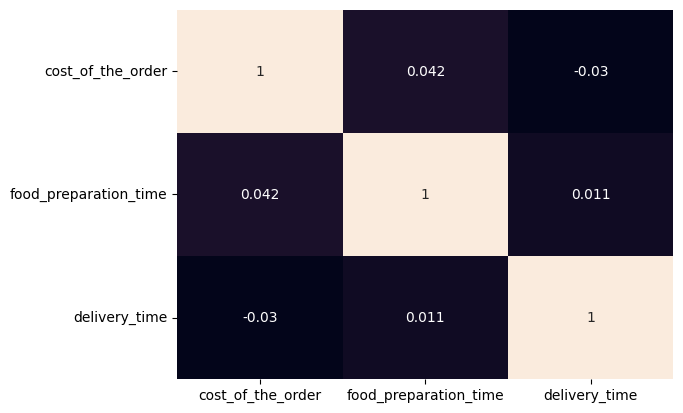

```python
#HEATMAP
sns.heatmap(df[['cost_of_the_order','food_preparation_time','delivery_time']].corr(), annot=  True, cbar = False)
plt.show()
```

#### Observations: The highest correlation was the cost of the order vs. food preparation time at 0.042 (which would mean there were no definitive positive or negative correlations). The lowest correlation was between the cost of the order vs. delivery time at. -0.03 (which would also mean there were no definitive positive/negative correlations).

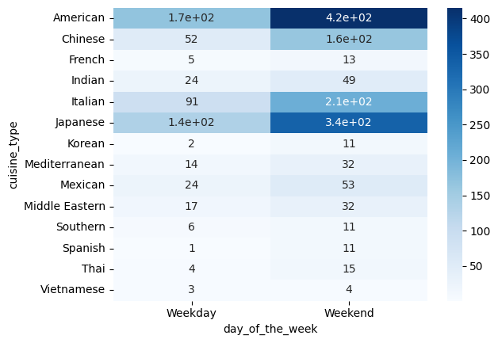

```python
sns.heatmap(pd.crosstab(df['cuisine_type'], df['day_of_the_week']), annot=True, cmap='Blues')
plt.show()
```

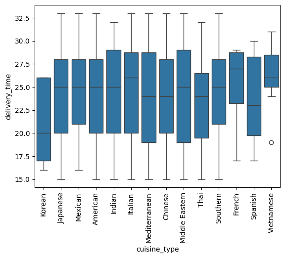

```python
sns.boxplot(data=df, x='cuisine_type', y='delivery_time')
plt.xticks(rotation=90)
plt.show()
```

#### Observations: Vietnamese food had an outlier for the delivery time at around 18.5 minutes. French cuisine had the highest median delivery time among the cuisines. Mediterranean and Middle Eastern cuisine had the biggest range of delivery time (making the delivery time unpredictable) while Vietnamese cuisine had the smallest range (which showed consistent delivery time).

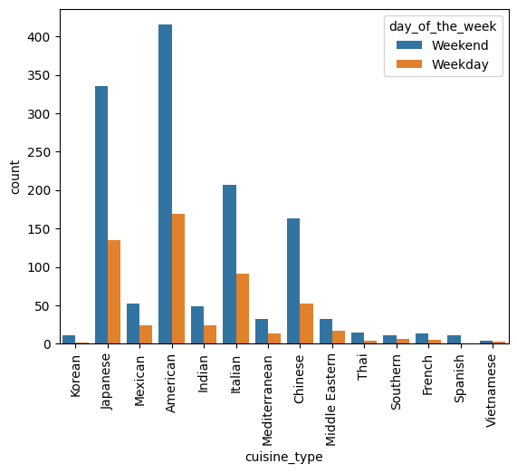

```python
sns.countplot(data=df, x='cuisine_type', hue='day_of_the_week')
plt.xticks(rotation=90)
plt.show()
```

#### Observations: Just like the heatmaps, this graph displayed the same results as the above graph. There were more orders placed on the weekends than the weekdays.

### **Question 13:** The company wants to provide a promotional offer in the advertisement of the restaurants. The condition to get the offer is that the restaurants must have a rating count of more than 50 and the average rating should be greater than 4. Find the restaurants fulfilling the criteria to get the promotional offer. [3 marks]

```python
df['rating'] = df['rating'].replace('Not given', np.nan) #to replace all the not given string with nan (this to change the entire column to float in the next line)
df['rating'] = df['rating'].astype(float) #this is to change the type from string to float in order to calculate mean and count
rating_total = df.groupby('restaurant_name')['rating'].agg(['count', 'mean']).reset_index() #since the promotion only shows the average rating provided, there will be no need to use the ratings that had no rating (this will prevent the missing numbers from affecting the mean)
restaurants_over_50 = rating_total[(rating_total['count'] > 50) & (rating_total['mean'] > 4)] #the conditions that needs to be met
qualified = restaurants_over_50.sort_values(by=['count', 'mean'], ascending=[False, False]) #sort by the order of count, then by mean
qualified['mean'] = qualified['mean'].round(2)
qualified = qualified.reset_index(drop=True)  # Reset existing index so the restaurant name number isn't shown (may confuse someone from understanding)
qualified.index = qualified.index + 1 #to rename the index from 0 to 1
qualified[['restaurant_name', 'count','mean']] #print the output
```

|  | restaurant_name | count | mean |
| --- | --- | --- | --- |
| 1 | Shake Shack | 133 | 4.28 |
| 2 | The Meatball Shop | 84 | 4.51 |
| 3 | Blue Ribbon Sushi | 73 | 4.22 |
| 4 | Blue Ribbon Fried Chicken | 64 | 4.33 |

### **Question 14:** The company charges the restaurant 25% on the orders having cost greater than 20 dollars and 15% on the orders having cost greater than 5 dollars. Find the net revenue generated by the company across all orders. [3 marks]

```python
def charges(cost_of_the_order): #to create a function that calculates based on condition
    if cost_of_the_order > 20: #for orders that are more than $20
        return cost_of_the_order * 0.25 #25% is applied
    elif cost_of_the_order > 5: #for orders that are more than $5 but lower than $20
        return cost_of_the_order * 0.15 #15% is applied
    else: #anything that is lower than or equal to $5
        return 0 #there is no effect on the prices
df['charges'] = df['cost_of_the_order'].apply(charges) # to apply the function to the cost of the order column
net_revenue = df['charges'].sum() #to calculate the net revenue of all orders
print("The net revenue generated by FoodHub is $" + str(round(net_revenue, 2)) + ".")
```

```
The net revenue generated by FoodHub is $6166.3.
```

#### Observations: FoodHub's net revenue is $6166.30.

### **Question 15:** The company wants to analyze the total time required to deliver the food. What percentage of orders take more than 60 minutes to get delivered from the time the order is placed? (The food has to be prepared and then delivered.) [2 marks]

```python
total_orders = len(df) #this shows the number of total orders in their respective rows
df['placed_and_delivered'] =df['food_preparation_time']+df['delivery_time']  #in order to calculate the total time, I added the delivery time and food preparation time dataframes together.
orders= df[df['placed_and_delivered'] > 60] #the condition
percentage = (len(orders) / total_orders) * 100 # to calculate percentage
print("The percentage of placed and delivered orders that took more than 60 minutes was " + str(round(percentage, 2)) + "%.")
```

```
The percentage of placed and delivered orders that took more than 60 minutes was 10.54%.
```

#### Observations: From the orders that were placed and delivered, 10.54% of the orders took a combined total (preparation time plus delivery time) of more than 60 minutes.

### **Question 16:** The company wants to analyze the delivery time of the orders on weekdays and weekends. How does the mean delivery time vary during weekdays and weekends? [2 marks]

```python
weekday = df[df['day_of_the_week'] == 'Weekday'] #to only collect all of the data that from the weekday
weekend = df[df['day_of_the_week'] == 'Weekend'] #to only collect all of the data that from the weekend
average_weekday = round(weekday['delivery_time'].mean(), 2) #to find the mean of the weekday
average_weekend = round(weekend['delivery_time'].mean(), 2) #to find the mean of the weekend
difference_average = round(average_weekday - average_weekend, 2) #to find the difference of the mean
print("The average delivery time on the weekday is", average_weekday,"minutes.")
print("The average delivery time on the weekend is", average_weekend,"minutes.")
print("There is a difference of", difference_average,"minutes.")
```

```
The average delivery time on the weekday is 28.34 minutes.
The average delivery time on the weekend is 22.47 minutes.
There is a difference of 5.87 minutes.
```

### Recommendations:

- Knowing that not many people rate food, I would offer promotions (ex: 5-10% discount for subsequent orders) for people to rate food (e.g. creating a star review system) to drive up FoodHub customer users.
- Since Vietnamese cuisine has low popularity but consistent time frame for delivery, I would incentivize people to order Vietnamese cuisine through promotional coupons (offers other options for users to try new things). This increases net revenue for FoodHub due to increased customer traffic for the restaurant.
- For restaurants struggling to get their name out to New York customers (only 4 restaurants qualified for discounted ads), encourage restaurant customers to leave reviews to ensure discount eligibility for restaurants running their ads on FoodHub.
- Create a reward system (e.g. every 2000 points = 20% off or free appetizer) where more orders raises the discount/free food they can get (increase users and profit for FoodHub).
- Seeing huge disparities in the delivery time, I would suggest hiring more drivers to decrease delivery time or to offer discounts on any orders that are higher than 25 minutes (improves customer's experience while keeping drivers accountable for getting deliveries done on time).